# 3_Analysis_GreenTrips

```python
import pandas as pd
import os
import numpy as np
import pandas_profiling

# This line is needed to display plots inline in Jupyter Notebook
%matplotlib inline

# Required for basic python plotting functionality
import matplotlib.pyplot as plt

# Required for formatting dates later in the case
import datetime
import matplotlib.dates as mdates

# Required to display image inline
from IPython.display import Image

# Advanced plotting functionality with seaborn
import seaborn as sns
sns.set(style="whitegrid") # can set style depending on how you'd like it to look

import folium  #needed for interactive map
from folium.plugins import HeatMap

import branca

import geopandas
from shapely.geometry import Polygon
from shapely.geometry import Point
from geopandas import GeoDataFrame

plotsize = (15,6)
```

```python
path = 'Dataset/Parquets'
green_trips = pd.read_parquet(path + '/green_trips_filtered.parquet', engine = 'pyarrow')
```

### Maps

#### Heatmap

```python
max_amount = float(green_trips['passenger_count'].max())

folium_hmap = folium.Map(location=[40.738, -73.98],
                        zoom_start=13,
                        tiles="OpenStreetMap")

hm_wide = HeatMap( list(zip(green_trips['pickup_latitude'], green_trips['pickup_longitude'],
                            green_trips['passenger_count'])),
                   min_opacity=0.2,
                   max_val=max_amount,
                   radius=8, blur=6,
                   max_zoom=15,
                 )

folium_hmap.add_child(hm_wide);
path = 'Results'
folium_hmap.save(path + "/Maps/heatmap_green_trips.html")
```

#### Markmap

```python
folium_map = folium.Map(location=[40.738, -73.98],
                        zoom_start=13,
                        tiles="OpenStreetMap")

green_trips = green_trips.reset_index()

for i in range(0,1000):
    marker = folium.CircleMarker(location=[green_trips["pickup_latitude"][i],
                                           green_trips["pickup_longitude"][i]],
                                 radius=5,color="b",fill=True)
    marker.add_to(folium_map)

path = 'Results'
folium_map.save(path + "/Maps/markmap_green_trips.html")
```

### Trip graphs

```python
path = 'Dataset/Parquets'
green_trips = pd.read_parquet(path + '/green_trips_nta.parquet', engine = 'pyarrow')
```

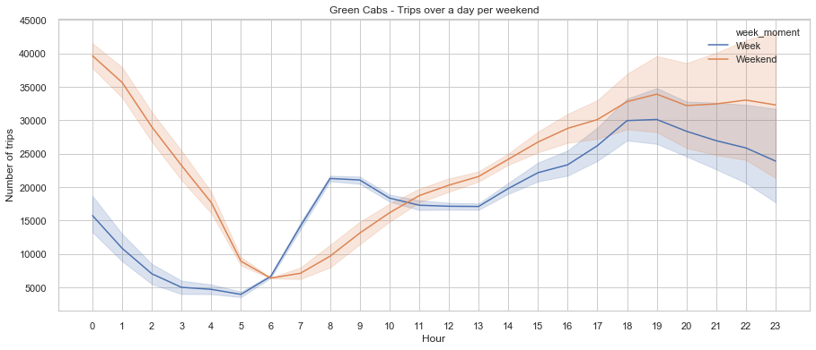

```python
green_trips['pickup_hour'] = green_trips['pickup_datetime'].dt.hour
green_trips['pickup_weekday'] = green_trips['pickup_datetime'].dt.dayofweek
green_trips['week_moment'] = np.where(green_trips['pickup_weekday'] <= 4, 'Week', 'Weekend')
green_trips['pickup_weekday'] = np.where(green_trips['pickup_weekday'] == 0, 'Monday',
                                           np.where(green_trips['pickup_weekday'] == 1, 'Tuesday',
                                                   np.where(green_trips['pickup_weekday'] == 2, 'Wednesday',
                                                           np.where(green_trips['pickup_weekday'] == 3, 'Thursday',
                                                                   np.where(green_trips['pickup_weekday'] == 4, 'Friday',
                                                                           np.where(green_trips['pickup_weekday'] == 5, 'Saturday', 'Sunday'))))))

Trips_hour = green_trips.groupby(['pickup_hour', 'pickup_weekday', 'week_moment'])['pickup_longitude'].count().reset_index()
#Accidents_Hour['HOUR'] = Accidents_Hour['HOUR'].astype('str')

fig, ax = plt.subplots(figsize = plotsize)
m = sns.lineplot(x="pickup_hour", y="pickup_longitude", hue = 'week_moment', data=Trips_hour, ax=ax)
ax.set(xlabel='Hour', ylabel='Number of trips')
ax.set_xticks(np.arange(0, 24,1))
#plt.xticks(rotation=90);
plt.xticks
#plt.ylim(0, 18000)
plt.title('Green Cabs - Trips over a day per weekend');
path = 'Results'
plt.savefig(path + '/Images/green_trips_hour_week.png')
```

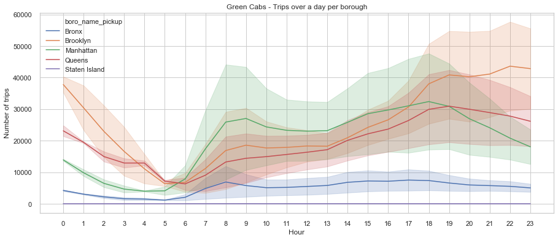

```python
green_trips['pickup_hour'] = green_trips['pickup_datetime'].dt.hour
green_trips['pickup_weekday'] = green_trips['pickup_datetime'].dt.dayofweek
green_trips['week_moment'] = np.where(green_trips['pickup_weekday'] <= 4, 'Week', 'Weekend')
green_trips['pickup_weekday'] = np.where(green_trips['pickup_weekday'] == 0, 'Monday',
                                           np.where(green_trips['pickup_weekday'] == 1, 'Tuesday',
                                                   np.where(green_trips['pickup_weekday'] == 2, 'Wednesday',
                                                           np.where(green_trips['pickup_weekday'] == 3, 'Thursday',
                                                                   np.where(green_trips['pickup_weekday'] == 4, 'Friday',
                                                                           np.where(green_trips['pickup_weekday'] == 5, 'Saturday', 'Sunday'))))))

Trips_hour = green_trips.groupby(['pickup_hour', 'boro_name_pickup', 'week_moment'])['pickup_longitude'].count().reset_index()
#Accidents_Hour['HOUR'] = Accidents_Hour['HOUR'].astype('str')
#Trips_hour = Trips_hour.loc[Trips_hour['boro_name_pickup'] != 'Manhattan']

fig, ax = plt.subplots(figsize = plotsize)
m = sns.lineplot(x="pickup_hour", y="pickup_longitude", hue = 'boro_name_pickup', data=Trips_hour, ax=ax)
ax.set(xlabel='Hour', ylabel='Number of trips')
ax.set_xticks(np.arange(0, 24,1))
#plt.xticks(rotation=90);
plt.xticks
#plt.ylim(0, 18000)
plt.title('Green Cabs - Trips over a day per borough');
path = 'Results'
plt.savefig(path + '/Images/green_trips_hour_borough.png')
```

#### Boxplots

```python
path = 'Dataset/Parquets'
green_trips = pd.read_parquet(path + '/green_trips_filtered.parquet', engine = 'pyarrow')
```

```python
green_trips['pickup_month_dt'] = pd.to_datetime(green_trips['pickup_datetime']).dt.to_period('M')
green_trips['pickup_date'] = pd.to_datetime(green_trips['pickup_datetime']).dt.to_period('d')
green_trips['pickup_hour'] = pd.to_datetime(green_trips['pickup_datetime']).dt.hour
green_trips['pickup_weekday'] = green_trips['pickup_datetime'].dt.dayofweek
green_trips['weekend'] = np.where(green_trips['pickup_weekday'] <= 4, False, True)
green_trips['rush'] = np.where(((green_trips['pickup_hour'] >= 6) & (green_trips['pickup_hour'] <= 9)) |
                               ((green_trips['pickup_hour'] >= 15) & (green_trips['pickup_hour'] <= 20)), True, False)
```

```python
green_trips_day = green_trips.groupby(['pickup_month_dt', 'pickup_date', 'weekend', 'rush'])['passenger_count'].count().reset_index(name = 'trips')
green_trips_day.head()
```

|  | pickup_month_dt | pickup_date | weekend | rush | trips |
| --- | --- | --- | --- | --- | --- |
| 0 | 2014-04 | 2014-04-01 | False | False | 3097 |
| 1 | 2014-04 | 2014-04-01 | False | True | 3607 |
| 2 | 2014-04 | 2014-04-02 | False | False | 3335 |
| 3 | 2014-04 | 2014-04-02 | False | True | 3726 |
| 4 | 2014-04 | 2014-04-03 | False | False | 3811 |

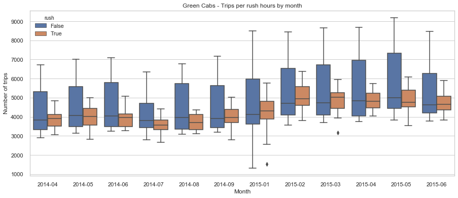

```python
fig, ax = plt.subplots(figsize = plotsize)
m = sns.boxplot(x="pickup_month_dt", y="trips", hue = 'rush', data=green_trips_day, ax=ax)
ax.set(xlabel='Month', ylabel='Number of trips')
#ax.set_xticks(np.arange(0, 24,1))
#plt.xticks(rotation=90);
plt.xticks
#plt.ylim(0, 18000)
plt.title('Green Cabs - Trips per rush hours by month');
path = 'Results'
plt.savefig(path + '/Images/green_trips_month_rush.png')
```

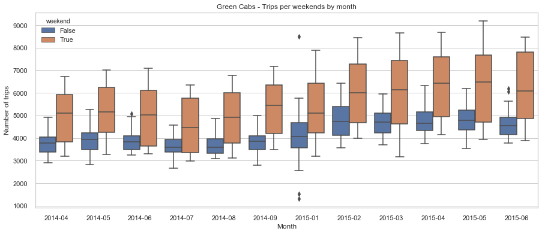

```python
fig, ax = plt.subplots(figsize = plotsize)
m = sns.boxplot(x="pickup_month_dt", y="trips", hue = 'weekend', data=green_trips_day, ax=ax)
ax.set(xlabel='Month', ylabel='Number of trips')
#ax.set_xticks(np.arange(0, 24,1))
#plt.xticks(rotation=90);
plt.xticks
#plt.ylim(0, 18000)
plt.title('Green Cabs - Trips per weekends by month');
path = 'Results'
plt.savefig(path + '/Images/green_trips_month_weekend.png')
```

```python
green_trips_day = green_trips.groupby(['pickup_month_dt', 'pickup_date'])['trip_distance'].mean().reset_index(name = 'avg_trip_distance')
green_trips_day.head()
```

|  | pickup_month_dt | pickup_date | avg_trip_distance |
| --- | --- | --- | --- |
| 0 | 2014-04 | 2014-04-01 | 2.994603 |
| 1 | 2014-04 | 2014-04-02 | 3.012497 |
| 2 | 2014-04 | 2014-04-03 | 2.997237 |
| 3 | 2014-04 | 2014-04-04 | 2.956694 |
| 4 | 2014-04 | 2014-04-05 | 3.240686 |

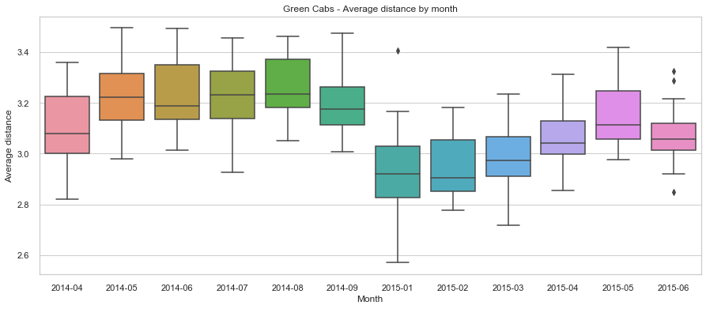

```python
fig, ax = plt.subplots(figsize = plotsize)
m = sns.boxplot(x="pickup_month_dt", y="avg_trip_distance", data=green_trips_day, ax=ax)
ax.set(xlabel='Month', ylabel='Average distance')
#ax.set_xticks(np.arange(0, 24,1))
#plt.xticks(rotation=90);
plt.xticks
#plt.ylim(0, 18000)
plt.title('Green Cabs - Average distance by month');
path = 'Results'
plt.savefig(path + '/Images/green_avgdistance_month.png')
```

```python
green_trips_day = green_trips.groupby(['pickup_month_dt', 'pickup_date'])['amount_per_distance'].mean().reset_index(name = 'avg_amount_per_distance')
green_trips_day.head()
```

|  | pickup_month_dt | pickup_date | avg_amount_per_distance |
| --- | --- | --- | --- |
| 0 | 2014-04 | 2014-04-01 | 5.887069 |
| 1 | 2014-04 | 2014-04-02 | 5.843344 |
| 2 | 2014-04 | 2014-04-03 | 5.929619 |
| 3 | 2014-04 | 2014-04-04 | 5.997868 |
| 4 | 2014-04 | 2014-04-05 | 5.624925 |

[figure not shown]

```python
plot_base = green_trips_day.copy()
plot_base['pickup_month_dt'] = plot_base['pickup_month_dt'].astype('str')

fig, ax = plt.subplots(figsize = plotsize)
m = sns.boxplot(x="pickup_month_dt", y="avg_amount_per_distance", data=plot_base, ax=ax)
ax.set(xlabel='Month', ylabel='Average amount per distance (USD/Mile)')
#ax.set_xticks(np.arange(0, 24,1))
#plt.xticks(rotation=90);
plt.xticks
#plt.ylim(2.5, 4)
plt.title('Green Cabs - Average amount per distance by months');
path = 'Results'
plt.savefig(path + '/Images/green_avgamountperdistance_month_boxplot.png')
```

```python
green_trips_day = green_trips.groupby(['pickup_month_dt', 'pickup_date', 'rush'])['amount_per_distance'].mean().reset_index(name = 'avg_amount_per_distance')
green_trips_day.head()
```

|  | pickup_month_dt | pickup_date | rush | avg_amount_per_distance |
| --- | --- | --- | --- | --- |
| 0 | 2014-04 | 2014-04-01 | False | 5.652344 |
| 1 | 2014-04 | 2014-04-01 | True | 6.088606 |
| 2 | 2014-04 | 2014-04-02 | False | 5.644134 |
| 3 | 2014-04 | 2014-04-02 | True | 6.021649 |
| 4 | 2014-04 | 2014-04-03 | False | 5.734912 |

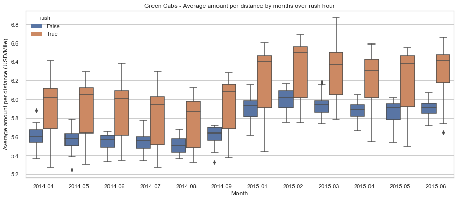

```python
plot_base = green_trips_day.copy()
plot_base['pickup_month_dt'] = plot_base['pickup_month_dt'].astype('str')

fig, ax = plt.subplots(figsize = plotsize)
m = sns.boxplot(x="pickup_month_dt", y="avg_amount_per_distance", hue = 'rush', data=plot_base, ax=ax)
ax.set(xlabel='Month', ylabel='Average amount per distance (USD/Mile)')
#ax.set_xticks(np.arange(0, 24,1))
#plt.xticks(rotation=90);
plt.xticks
#plt.ylim(2.5, 4)
plt.title('Green Cabs - Average amount per distance by months over rush hour');
path = 'Results'
plt.savefig(path + '/Images/green_avgamountperdistance_rush_month_boxplot.png')
```

```python
green_trips_day = green_trips.groupby(['pickup_month_dt', 'pickup_date', 'weekend'])['amount_per_distance'].mean().reset_index(name = 'avg_amount_per_distance')
green_trips_day.head()
```

|  | pickup_month_dt | pickup_date | weekend | avg_amount_per_distance |
| --- | --- | --- | --- | --- |
| 0 | 2014-04 | 2014-04-01 | False | 5.887069 |
| 1 | 2014-04 | 2014-04-02 | False | 5.843344 |
| 2 | 2014-04 | 2014-04-03 | False | 5.929619 |
| 3 | 2014-04 | 2014-04-04 | False | 5.997868 |
| 4 | 2014-04 | 2014-04-05 | True | 5.624925 |

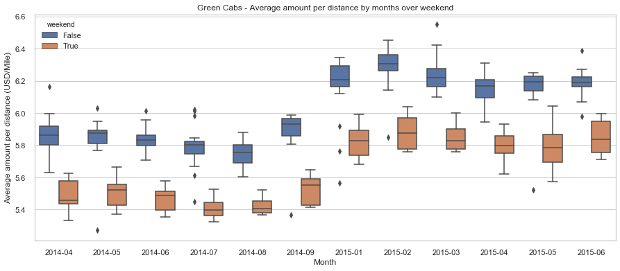

```python
plot_base = green_trips_day.copy()
plot_base['pickup_month_dt'] = plot_base['pickup_month_dt'].astype('str')

fig, ax = plt.subplots(figsize = plotsize)
m = sns.boxplot(x="pickup_month_dt", y="avg_amount_per_distance", hue = 'weekend', data=plot_base, ax=ax)
ax.set(xlabel='Month', ylabel='Average amount per distance (USD/Mile)')
#ax.set_xticks(np.arange(0, 24,1))
#plt.xticks(rotation=90);
plt.xticks
#plt.ylim(2.5, 4)
plt.title('Green Cabs - Average amount per distance by months over weekend');
path = 'Results'
plt.savefig(path + '/Images/green_avgamountperdistance_weekend_month_boxplot.png')
```

### Hipothesys testing

**Objective:** Compare the distance traveled between 201404 and 201406 with the one between 201504 and 201506

```python
path = 'Dataset/Parquets'
green_trips = pd.read_parquet(path + '/green_trips_filtered.parquet', engine = 'pyarrow')
green_trips['pickup_month_dt'] = pd.to_datetime(green_trips['pickup_datetime']).dt.to_period('M')
green_trips['pickup_date'] = pd.to_datetime(green_trips['pickup_datetime']).dt.to_period('d')
green_trips['pickup_hour'] = pd.to_datetime(green_trips['pickup_datetime']).dt.hour
green_trips['pickup_weekday'] = green_trips['pickup_datetime'].dt.dayofweek
green_trips['weekend'] = np.where(green_trips['pickup_weekday'] <= 4, False, True)
green_trips['rush'] = np.where(((green_trips['pickup_hour'] >= 6) & (green_trips['pickup_hour'] <= 9)) |
                               ((green_trips['pickup_hour'] >= 15) & (green_trips['pickup_hour'] <= 20)), True, False)
```

```python
green_trips.dtypes
```

```
pickup_datetime        datetime64[ns]
dropoff_datetime       datetime64[ns]
pickup_longitude              float64
pickup_latitude               float64
dropoff_longitude             float64
dropoff_latitude              float64
passenger_count                 int64
trip_distance                 float64
total_amount                  float64
pickup_month                    int64
dropoff_month                   int64
amount_per_distance           float64
pickup_month_dt             period[M]
pickup_date                 period[D]
pickup_hour                     int64
pickup_weekday                  int64
weekend                          bool
rush                             bool
dtype: object
```

```python
green_trips_201404_201406 = green_trips.loc[(green_trips['pickup_datetime'] >= '01/04/2014') & (green_trips['pickup_datetime'] <= '30/06/2014')]
green_trips_201504_201506 = green_trips.loc[(green_trips['pickup_datetime'] >= '01/04/2015') & (green_trips['pickup_datetime'] <= '30/06/2015')]
```

```python
green_trips_201404_201406.pickup_datetime.min()
green_trips_201404_201406.pickup_datetime.max()
```

```
Timestamp('2014-06-30 00:00:00')
```

$$H_0: \mu_1=\mu_2$$$$H_a: \mu_1 \neq \mu_2$$

```python
from scipy import stats
statistic, pvalue = stats.ttest_ind(green_trips_201404_201406.trip_distance,
                                    green_trips_201504_201506.trip_distance,
                                    equal_var=False)
statistic, pvalue
```

```
(39.19449696292198, 0.0)
```

**Hypothesis:** The distance of the trips that took place in weekends is statistically similar with the ones in weekdays

$$H_0: \mu_1=\mu_2$$$$H_a: \mu_1 \neq \mu_2$$

```python
green_trips_weekend = green_trips.loc[(green_trips['weekend'] == True)]
green_trips_week = green_trips.loc[(green_trips['weekend'] == False)]

print(green_trips_weekend.trip_distance.mean())
print(green_trips_week.trip_distance.mean())
```

```
3.253455678880302
3.051915827090351
```

```python
from scipy import stats
statistic, pvalue = stats.ttest_ind(green_trips_weekend.trip_distance,
                                    green_trips_week.trip_distance,
                                    equal_var=False)
statistic, pvalue
```

```
(58.39754897791502, 0.0)
```

**Conclusion:** There is enough statistical evidence to assert that the distance of the trips that took place in weekends is statistically **different** with the ones in weekdays

**Hypothesis:** The distance of the trips that took place in rush hours is statistically similar with the ones in non-rush hours

$$H_0: \mu_1=\mu_2$$$$H_a: \mu_1 \neq \mu_2$$

```python
green_trips_rush = green_trips.loc[(green_trips['rush'] == True)]
green_trips_norush = green_trips.loc[(green_trips['rush'] == False)]
```

```python
from scipy import stats
statistic, pvalue = stats.ttest_ind(green_trips_rush.trip_distance,
                                    green_trips_norush.trip_distance,
                                    equal_var=False)
statistic, pvalue
```

```
(-50.082351772032396, 0.0)
```

**Conclusion:** There is enough statistical evidence to assert that the distance of the trips that took place in rush hours is statistically **different** with the ones in non-rush hours

# Maps for NTA analysis

## Pick-up Analysis

```python
path = 'Dataset/Parquets'
green_trips = pd.read_parquet(path + '/green_trips_nta.parquet', engine = 'pyarrow')

# Opens the map as a GeoDataFrame
path = 'Dataset/Original'
nyc_bouroughs = geopandas.read_file(path + '/Neighborhood Tabulation Areas.geojson')
```

```python
green_trips_nta.head()
```

[output not shown]

```python
green_trips_nta = green_trips.groupby('ntacode_pickup')['pickup_datetime'].count().reset_index(name = 'trips')
green_trips_nta.rename({'ntacode_pickup':'ntacode'}, inplace = True, axis = 1)

nyc_bouroughs_trips = nyc_bouroughs.merge(green_trips_nta, how = 'left', on = 'ntacode')
nyc_bouroughs_trips['trips'].fillna(0, inplace = True)
nyc_bouroughs_trips.head()
```

|  | ntacode | shape_area | county_fips | ntaname | shape_leng | boro_name | boro_code | geometry | trips |
| --- | --- | --- | --- | --- | --- | --- | --- | --- | --- |
| 0 | BK88 | 54005018.7472 | 047 | Borough Park | 39247.2280737 | Brooklyn | 3 | MULTIPOLYGON (((-73.97605 40.63128, -73.97717 ... | 1090.0 |
| 1 | QN51 | 52488276.477 | 081 | Murray Hill | 33266.904811 | Queens | 4 | MULTIPOLYGON (((-73.80379 40.77561, -73.80099 ... | 397.0 |
| 2 | QN27 | 19726845.26 | 081 | East Elmhurst | 19816.7115378 | Queens | 4 | MULTIPOLYGON (((-73.86110 40.76366, -73.85993 ... | 4494.0 |
| 3 | QN07 | 22887772.7683 | 081 | Hollis | 20976.3358374 | Queens | 4 | MULTIPOLYGON (((-73.75726 40.71814, -73.75589 ... | 197.0 |
| 4 | MN06 | 10647077.6122 | 061 | Manhattanville | 17040.6865482 | Manhattan | 1 | MULTIPOLYGON (((-73.94608 40.82126, -73.94640 ... | 29576.0 |

```python
# interactive visualization for beat-specific crime rate in 2017

m_trips = folium.Map(location=[40.738, -73.98],
                        zoom_start=11,
                        tiles="OpenStreetMap")

colormap = branca.colormap.LinearColormap(
    colors=['white','yellow','orange','red','darkred'],
    #index=beat_cn['count'].quantile([0.2,0.4,0.6,0.8]),b
    vmin=nyc_bouroughs_trips.trips.min(),
    vmax=nyc_bouroughs_trips.trips.max()
)

style_function = lambda x: {
    'fillColor': colormap(x['properties']['trips']),
    'color': 'black',
    'weight':2,
    'fillOpacity':0.5
}

stategeo = folium.GeoJson(
    nyc_bouroughs_trips.to_json(),
    name='Chicago beats',
    style_function=style_function,
    tooltip=folium.GeoJsonTooltip(
        fields=['boro_name', 'ntaname', 'trips'],
        aliases=['Borough', 'NTA', 'Total trips'],
        localize=True
    )
).add_to(m_trips)

colormap.add_to(m_trips)

path = 'Results'
m_trips.save(path + "/Maps/trips_nta_green_map.html")
```

```python
# nta_code population
path = 'Dataset/Original'
demographics = pd.read_csv(path + '/demographics.csv', sep = ',', doublequote = True)
```

```python
nyc_bouroughs_demo = nyc_bouroughs_trips.merge(demographics, how = 'left',
                                               left_on = 'ntacode', right_on = 'nta_code')
nyc_bouroughs_demo.population.fillna(0, inplace = True)
nyc_bouroughs_demo.head()
```

|  | ntacode | shape_area | county_fips | ntaname | shape_leng | boro_name | boro_code | geometry | trips | nta_name | ... | 15000_to_24999 | 25000_to_34999 | 35000_to_49999 | 50000_to_74999 | 75000_to_99999 | 100000_to_149999 | 150000_to_199999 | 200000_or_more | median_income | mean_income |
| --- | --- | --- | --- | --- | --- | --- | --- | --- | --- | --- | --- | --- | --- | --- | --- | --- | --- | --- | --- | --- | --- |
| 0 | BK88 | 54005018.7472 | 047 | Borough Park | 39247.2280737 | Brooklyn | 3 | MULTIPOLYGON (((-73.97605 40.63128, -73.97717 ... | 1090.0 | Borough Park | ... | 4893.0 | 3850.0 | 3711.0 | 4098.0 | 2136.0 | 2486.0 | 1043.0 | 783.0 | 35754.0 | 55689.0 |
| 1 | QN51 | 52488276.477 | 081 | Murray Hill | 33266.904811 | Queens | 4 | MULTIPOLYGON (((-73.80379 40.77561, -73.80099 ... | 397.0 | Murray Hill | ... | 1665.0 | 2443.0 | 2151.0 | 2850.0 | 2140.0 | 2233.0 | 1031.0 | 906.0 | 52696.0 | 71925.0 |
| 2 | QN27 | 19726845.26 | 081 | East Elmhurst | 19816.7115378 | Queens | 4 | MULTIPOLYGON (((-73.86110 40.76366, -73.85993 ... | 4494.0 | East Elmhurst | ... | 617.0 | 730.0 | 1004.0 | 1173.0 | 860.0 | 766.0 | 295.0 | 128.0 | 51594.0 | 66284.0 |
| 3 | QN07 | 22887772.7683 | 081 | Hollis | 20976.3358374 | Queens | 4 | MULTIPOLYGON (((-73.75726 40.71814, -73.75589 ... | 197.0 | Hollis | ... | 561.0 | 559.0 | 723.0 | 1204.0 | 655.0 | 1086.0 | 492.0 | 223.0 | 59368.0 | 75975.0 |
| 4 | MN06 | 10647077.6122 | 061 | Manhattanville | 17040.6865482 | Manhattan | 1 | MULTIPOLYGON (((-73.94608 40.82126, -73.94640 ... | 29576.0 | Manhattanville | ... | 943.0 | 918.0 | 1303.0 | 917.0 | 599.0 | 421.0 | 168.0 | 79.0 | 29182.0 | 40748.0 |

5 rows × 42 columns

```python
nyc_bouroughs_demo['trips_population'] = np.where(nyc_bouroughs_demo['population'] == 0, 0, nyc_bouroughs_demo['trips']/nyc_bouroughs_demo['population'])
```

```python
# interactive visualization for beat-specific crime rate in 2017

m_trips = folium.Map(location=[40.738, -73.98],
                        zoom_start=11,
                        tiles="OpenStreetMap")

colormap = branca.colormap.LinearColormap(
    colors=['white','yellow','orange','red','darkred'],
    #index=beat_cn['count'].quantile([0.2,0.4,0.6,0.8]),b
    vmin=nyc_bouroughs_demo.trips_population.min(),
    vmax=nyc_bouroughs_demo.trips_population.max()
)

style_function = lambda x: {
    'fillColor': colormap(x['properties']['trips_population']),
    'color': 'black',
    'weight':2,
    'fillOpacity':0.5
}

stategeo = folium.GeoJson(
    nyc_bouroughs_demo.to_json(),
    name='Chicago beats',
    style_function=style_function,
    tooltip=folium.GeoJsonTooltip(
        fields=['boro_name', 'ntaname', 'trips_population'],
        aliases=['Borough', 'NTA', 'Total trips per population'],
        localize=True
    )
).add_to(m_trips)

colormap.add_to(m_trips)

path = 'Results'
m_trips.save(path + "/Maps/trips_pop_nta_green_map.html")
```

```python
path = 'DataSet/Parquets'
nyc_bouroughs_demo_save = nyc_bouroughs_demo.copy()
nyc_bouroughs_demo_save.drop('geometry', axis = 1, inplace = True)
nyc_bouroughs_demo_save.to_parquet(path + '/nyc_bouroughs_trips_green.parquet', engine = 'pyarrow')
```

## Drop-off Analysis

```python
green_trips_nta = green_trips.groupby('ntacode_dropoff')['dropoff_datetime'].count().reset_index(name = 'trips')
green_trips_nta.rename({'ntacode_dropoff':'ntacode'}, inplace = True, axis = 1)

nyc_bouroughs_trips = nyc_bouroughs.merge(green_trips_nta, how = 'left', on = 'ntacode')
nyc_bouroughs_trips['trips'].fillna(0, inplace = True)
nyc_bouroughs_trips.head()
```

|  | ntacode | shape_area | county_fips | ntaname | shape_leng | boro_name | boro_code | geometry | trips |
| --- | --- | --- | --- | --- | --- | --- | --- | --- | --- |
| 0 | BK88 | 54005018.7472 | 047 | Borough Park | 39247.2280737 | Brooklyn | 3 | MULTIPOLYGON (((-73.97605 40.63128, -73.97717 ... | 3090.0 |
| 1 | QN51 | 52488276.477 | 081 | Murray Hill | 33266.904811 | Queens | 4 | MULTIPOLYGON (((-73.80379 40.77561, -73.80099 ... | 5605.0 |
| 2 | QN27 | 19726845.26 | 081 | East Elmhurst | 19816.7115378 | Queens | 4 | MULTIPOLYGON (((-73.86110 40.76366, -73.85993 ... | 16714.0 |
| 3 | QN07 | 22887772.7683 | 081 | Hollis | 20976.3358374 | Queens | 4 | MULTIPOLYGON (((-73.75726 40.71814, -73.75589 ... | 997.0 |
| 4 | MN06 | 10647077.6122 | 061 | Manhattanville | 17040.6865482 | Manhattan | 1 | MULTIPOLYGON (((-73.94608 40.82126, -73.94640 ... | 28482.0 |

```python
# interactive visualization for beat-specific crime rate in 2017

m_trips = folium.Map(location=[40.738, -73.98],
                        zoom_start=11,
                        tiles="OpenStreetMap")

colormap = branca.colormap.LinearColormap(
    colors=['white','yellow','orange','red','darkred'],
    #index=beat_cn['count'].quantile([0.2,0.4,0.6,0.8]),b
    vmin=nyc_bouroughs_trips.trips.min(),
    vmax=nyc_bouroughs_trips.trips.max()
)

style_function = lambda x: {
    'fillColor': colormap(x['properties']['trips']),
    'color': 'black',
    'weight':2,
    'fillOpacity':0.5
}

stategeo = folium.GeoJson(
    nyc_bouroughs_trips.to_json(),
    name='Chicago beats',
    style_function=style_function,
    tooltip=folium.GeoJsonTooltip(
        fields=['boro_name', 'ntaname', 'trips'],
        aliases=['Borough', 'NTA', 'Total trips'],
        localize=True
    )
).add_to(m_trips)

colormap.add_to(m_trips)

path = 'Results'
m_trips.save(path + "/Maps/trips_nta_green_dropoff_map.html")
```

```python
# nta_code population
path = 'Dataset/Original'
demographics = pd.read_csv(path + '/demographics.csv', sep = ',', doublequote = True)
```

```python
nyc_bouroughs_demo = nyc_bouroughs_trips.merge(demographics, how = 'left',
                                               left_on = 'ntacode', right_on = 'nta_code')
nyc_bouroughs_demo.population.fillna(0, inplace = True)
nyc_bouroughs_demo.head()
```

|  | ntacode | shape_area | county_fips | ntaname | shape_leng | boro_name | boro_code | geometry | trips | nta_name | ... | 15000_to_24999 | 25000_to_34999 | 35000_to_49999 | 50000_to_74999 | 75000_to_99999 | 100000_to_149999 | 150000_to_199999 | 200000_or_more | median_income | mean_income |
| --- | --- | --- | --- | --- | --- | --- | --- | --- | --- | --- | --- | --- | --- | --- | --- | --- | --- | --- | --- | --- | --- |
| 0 | BK88 | 54005018.7472 | 047 | Borough Park | 39247.2280737 | Brooklyn | 3 | MULTIPOLYGON (((-73.97605 40.63128, -73.97717 ... | 3090.0 | Borough Park | ... | 4893.0 | 3850.0 | 3711.0 | 4098.0 | 2136.0 | 2486.0 | 1043.0 | 783.0 | 35754.0 | 55689.0 |
| 1 | QN51 | 52488276.477 | 081 | Murray Hill | 33266.904811 | Queens | 4 | MULTIPOLYGON (((-73.80379 40.77561, -73.80099 ... | 5605.0 | Murray Hill | ... | 1665.0 | 2443.0 | 2151.0 | 2850.0 | 2140.0 | 2233.0 | 1031.0 | 906.0 | 52696.0 | 71925.0 |
| 2 | QN27 | 19726845.26 | 081 | East Elmhurst | 19816.7115378 | Queens | 4 | MULTIPOLYGON (((-73.86110 40.76366, -73.85993 ... | 16714.0 | East Elmhurst | ... | 617.0 | 730.0 | 1004.0 | 1173.0 | 860.0 | 766.0 | 295.0 | 128.0 | 51594.0 | 66284.0 |
| 3 | QN07 | 22887772.7683 | 081 | Hollis | 20976.3358374 | Queens | 4 | MULTIPOLYGON (((-73.75726 40.71814, -73.75589 ... | 997.0 | Hollis | ... | 561.0 | 559.0 | 723.0 | 1204.0 | 655.0 | 1086.0 | 492.0 | 223.0 | 59368.0 | 75975.0 |
| 4 | MN06 | 10647077.6122 | 061 | Manhattanville | 17040.6865482 | Manhattan | 1 | MULTIPOLYGON (((-73.94608 40.82126, -73.94640 ... | 28482.0 | Manhattanville | ... | 943.0 | 918.0 | 1303.0 | 917.0 | 599.0 | 421.0 | 168.0 | 79.0 | 29182.0 | 40748.0 |

5 rows × 42 columns

```python
nyc_bouroughs_demo['trips_population'] = np.where(nyc_bouroughs_demo['population'] == 0, 0, nyc_bouroughs_demo['trips']/nyc_bouroughs_demo['population'])
```

```python
path = 'DataSet/Parquets'
nyc_bouroughs_demo_save = nyc_bouroughs_demo.copy()
nyc_bouroughs_demo_save.drop('geometry', axis = 1, inplace = True)
nyc_bouroughs_demo_save.to_parquet(path + '/nyc_bouroughs_trips_green_dropoff.parquet', engine = 'pyarrow')
```